# ODE integration and sensitivity analysis

## Basic ODE integration

We will use `solve_ivp` function from SciPy for solving ODEs. It supports:

- Initial value problems (IVPs)
- Stiff and non-stiff problems
- Various integration methods: `RK45`, `RK23`, `Radau`, `BDF`, `LSODA`

It requires:

- A function that defines your differential equation.
- The time range over which you want to solve the ODE.
- The starting value of your system, e.g. a list or array of initial conditions.
- The integration method.
- A NumPy array of time points at which to store the solution. If not set, it only returns a few key points.

Let's try to solve the following differential equation with parameter $k=0.4$ and initial condition $y_{0} = 6$:

$$ \frac{dy}{dt} = -ky $$

```python
import numpy as np
from scipy.integrate import solve_ivp
import matplotlib.pyplot as plt

# define the ODE
def model(t, y):
    k = 0.4
    return -k * y

# time interval and initial condition
t_span = (0, 30)
y0 = [6]

# define time points at which to evaluate the solution
t_eval = np.linspace(t_span[0], t_span[1], 100)

# solve the ODE
sol = solve_ivp(model, t_span, y0, method='RK45', t_eval=t_eval)
```

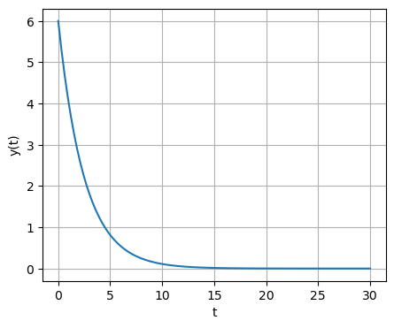

```python
# plot
plt.figure(figsize=(5,4))
plt.plot(sol.t, sol.y[0])
plt.xlabel('t')
plt.ylabel('y(t)')
plt.grid(True)
plt.show()
```

An optional input of `solve_ivp` function is `args` that allows additional information to be passed into the model function.

The `args` input is a tuple sequence of values.

```python
def model(t, y, k):
    dydt = -k*y
    return dydt
```

```python
k = 0.1
sol1 = solve_ivp(model, t_span, y0, args=(k,), method='RK45', t_eval=t_eval)

k = 0.3
sol2 = solve_ivp(model, t_span, y0, args=(k,), method='RK45', t_eval=t_eval)

k = 0.6
sol3 = solve_ivp(model, t_span, y0, args=(k,), method='RK45', t_eval=t_eval)
```

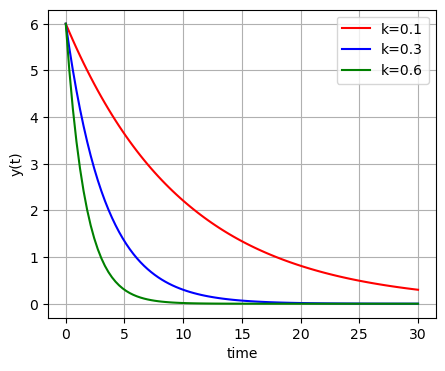

```python
plt.figure(figsize=(5,4))
plt.plot(sol1.t, sol1.y[0], 'r', label='k=0.1')
plt.plot(sol2.t, sol2.y[0], 'b', label='k=0.3')
plt.plot(sol3.t, sol3.y[0], 'g', label='k=0.6')
plt.xlabel('time')
plt.ylabel('y(t)')
plt.grid(True)
plt.legend(loc='best')
plt.show()
```

## Logistic growth

The logistic growth is a classic model used to describe how a population grows in an environment with **limited resources**.

$$ \frac{dy}{dt} = ry\left( 1 - \frac{y}{k} \right)$$

where $y(t)$ is the size of the population at time $t$, $r$ is the growth rate and $k$ is the carrying capacity, that is the number of people, other living organisms, or crops that a region can support without environmental degradation.

```python
def logistic(t, y, r, k):
    dydt = r*y*(1 - y/k)
    return dydt
```

```python
# initial condition
y0 = [10]

# time interval
t_span = (0, 120)

# time points at which to evaluate the solution
t_eval = np.linspace(t_span[0], t_span[1], 200)

# parameters
r = 0.1
k = 1500

# solve ODE
sol = solve_ivp(logistic, t_span, y0, args=(r, k), method='RK45',
                t_eval=t_eval)
```

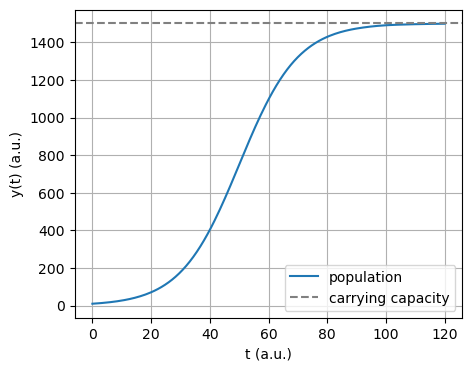

```python
# plot
plt.figure(figsize=(5,4))
plt.plot(sol.t, sol.y[0], label='population')
plt.xlabel('t (a.u.)')
plt.ylabel('y(t) (a.u.)')
plt.grid(True)
plt.axhline(k, label='carrying capacity', color='gray', linestyle='--')
plt.legend(loc='best')
plt.show()
```

# Sensitivity analysis of ODE

Sensitivity analysis for ODEs helps you understand how sensitive the solution of an ODE is to changes in its parameters. This is useful in modeling and simulations, especially in contexts where parameters are often estimated or uncertain.

It is convenient to transform the result of the integration in a `pandas` dataframe.

This allows us to use it for better visualization through `seaborn`.

```python
import pandas as pd

def create_df(result, columns, **other_info):
    df = pd.DataFrame(result, columns=columns)
    for key, value in other_info.items():
        df[key] = value
    return df
```

```python
create_df(sol.y[0], ['population'], r=r, k=k, time=sol.t).head()
```

|  | population | r | k | time |
| --- | --- | --- | --- | --- |
| 0 | 10.000000 | 0.1 | 1500 | 0.000000 |
| 1 | 10.617168 | 0.1 | 1500 | 0.603015 |
| 2 | 11.272137 | 0.1 | 1500 | 1.206030 |
| 3 | 11.967188 | 0.1 | 1500 | 1.809045 |
| 4 | 12.704818 | 0.1 | 1500 | 2.412060 |

```python
# randomly generate 50 normally distributed values of r
rates = np.random.normal(r, 0.02, 50)

results = []
idx = 0
for ri in rates:
    sols = solve_ivp(logistic, t_span, y0, args=(ri, k), method='RK45',
                     t_eval=t_eval)
    ys_df = create_df(sols.y[0], ['population'], r=ri, k=k, time=sols.t,
                      simulation_run=idx)
    results.append(ys_df)
    idx = idx + 1
results = pd.concat(results, ignore_index=True)
```

```python
results
```

|  | population | r | k | time | simulation_run |
| --- | --- | --- | --- | --- | --- |
| 0 | 10.000000 | 0.074285 | 1500 | 0.000000 | 0 |
| 1 | 10.454944 | 0.074285 | 1500 | 0.603015 | 0 |
| 2 | 10.930433 | 0.074285 | 1500 | 1.206030 | 0 |
| 3 | 11.427382 | 0.074285 | 1500 | 1.809045 | 0 |
| 4 | 11.946783 | 0.074285 | 1500 | 2.412060 | 0 |
| ... | ... | ... | ... | ... | ... |
| 9995 | 1499.782687 | 0.147591 | 1500 | 117.587940 | 49 |
| 9996 | 1499.801191 | 0.147591 | 1500 | 118.190955 | 49 |
| 9997 | 1499.818118 | 0.147591 | 1500 | 118.793970 | 49 |
| 9998 | 1499.833604 | 0.147591 | 1500 | 119.396985 | 49 |
| 9999 | 1499.847771 | 0.147591 | 1500 | 120.000000 | 49 |

10000 rows × 5 columns

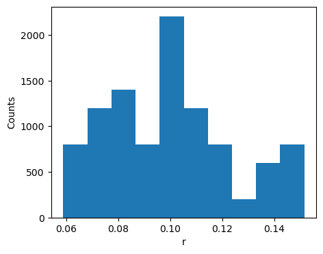

```python
plt.figure(figsize=(5,4))
plt.hist(results['r'], bins=10)
plt.ylabel('Counts')
plt.xlabel('r')
plt.show()
```

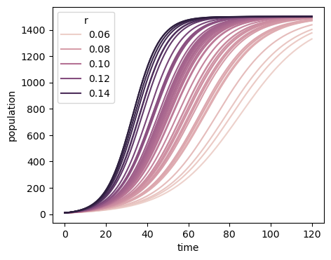

```python
import seaborn as sns

plt.figure(figsize=(5,4))
sns.lineplot(x="time", y="population", data=results, hue='r',
             estimator=None, units='simulation_run')
plt.show()
```

```python
# randomly generate 50 normally distributed values of k
capacities = np.random.normal(k, 100, 50)

results = []
idx = 0
for ci in capacities:
    sols = solve_ivp(logistic, t_span, y0, args=(r, ci), method='RK45',
                     t_eval=t_eval)
    ys_df = create_df(sols.y[0], ['population'], r=r, k=ci, time=sols.t,
                      simulation_run=idx)
    results.append(ys_df)
    idx = idx + 1
results = pd.concat(results, ignore_index=True)
```

```python
results
```

|  | population | r | k | time | simulation_run |
| --- | --- | --- | --- | --- | --- |
| 0 | 10.000000 | 0.1 | 1496.719613 | 0.000000 | 0 |
| 1 | 10.617158 | 0.1 | 1496.719613 | 0.603015 | 0 |
| 2 | 11.272116 | 0.1 | 1496.719613 | 1.206030 | 0 |
| 3 | 11.967153 | 0.1 | 1496.719613 | 1.809045 | 0 |
| 4 | 12.704768 | 0.1 | 1496.719613 | 2.412060 | 0 |
| ... | ... | ... | ... | ... | ... |
| 9995 | 1519.292176 | 0.1 | 1521.195272 | 117.587940 | 49 |
| 9996 | 1519.402445 | 0.1 | 1521.195272 | 118.190955 | 49 |
| 9997 | 1519.506375 | 0.1 | 1521.195272 | 118.793970 | 49 |
| 9998 | 1519.604471 | 0.1 | 1521.195272 | 119.396985 | 49 |
| 9999 | 1519.697225 | 0.1 | 1521.195272 | 120.000000 | 49 |

10000 rows × 5 columns

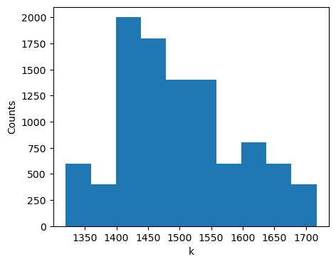

```python
plt.figure(figsize=(5,4))
plt.hist(results['k'], bins=10)
plt.ylabel('Counts')
plt.xlabel('k')
plt.show()
```

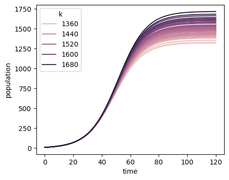

```python
plt.figure(figsize=(5,4))
sns.lineplot(x="time", y="population", data=results, hue='k',
             estimator=None, units='simulation_run')
plt.show()
```